# car_count

Nathan Grossman

January 22, 2018

### Overview

This notebook analyzes data on the number of cars observed in a retail location parking lot, chiefly as a time series and briefly as a function of other variables observed. The following sections of this notebook: (1) begin with the methods and R code used to obtain information of interest; (2) proceed to plots and/or print-outs to display the information; and (3) end with a sub-section labelled **Discusion** containing insights from and commentary on the information. Readers who are not interested in the low-level details can proceed directly to the **Discussion** sub-sections for the high-level analyses.

#### Environment Initialization

```r
knitr::opts_chunk$set(echo = TRUE)
library(zoo)
library(xts)
library(forecast)
library(lubridate)
library(forcats)
setwd("C:/Users/Nathan/RStudioProjects/orbital_insight")
rm(list=ls())
options(max.print=150)
```

### Data Preparation

Read data into dataframe

```r
dataDF = read.csv("data.csv")
```

Cast date column of dataframe as date data type

```r
dataDF$date = as.Date(dataDF$date, format='%Y-%m-%d')
```

Create XTS time series object, for plotting and later use

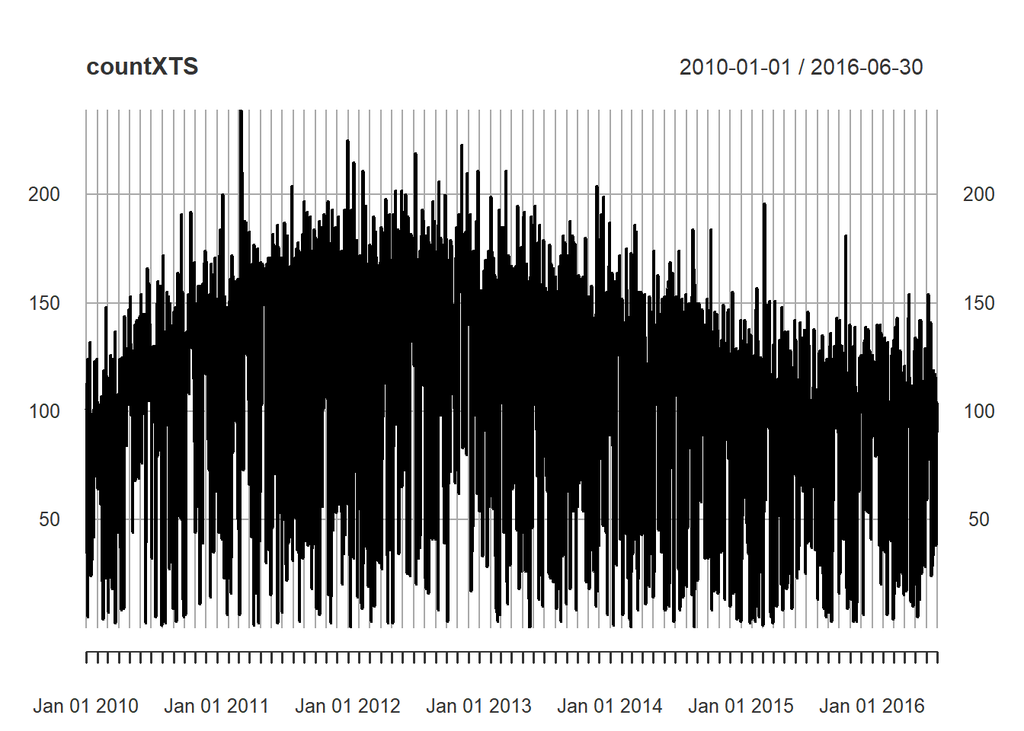

```r
countXTS = xts(dataDF$car.count, dataDF$date)
plot(countXTS)
```

#### Discussion

The above plot of the car count time series seems to show seasonality, as there appear to be cyclical variations in the series, as well as longer term trends, as the central tendency of the series appears to increase between 2010 and 2012, and then to decrease between 2013 and 2016. The initial upward trend may refect the recovery of the economy after the Great Recession, while the subsequent downward trend may reflect the decline in retail during the latter half of the decade (but these observations are highly speculative).

Since the magnitude of the cyclical variation does not appear to vary dramatically over time with the central tendency, an additive model of the series in terms of trend and seasonal components appears appropriate (or at least more appropriate than a multiplicative model as a first pass). Since the parking lot is situated at a retail location, and since consumer behavior varies during the week and over the year, both weekly and annual seasonality components appear plausible.

### Time Series Decomposition

Decompose car count time series assuming an additive model with a trend component and a seasonal component, of the form  
y(t) = b(t) + s(t) + e(t)  
where b(t) is the trend, s(t) is the seasonality and e(t) is the error

*First, assume the dominant seasonality (cyclicality) is weekly, so there are 7 (daily) observations per season (cycle)*

Create time series object under weekly seasonality assumption

```r
countTS7 = ts(dataDF$car.count, freq=7)
```

Decompose time series into trend and weekly seasonal components

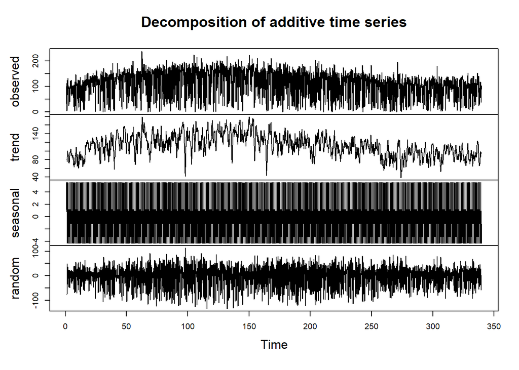

```r
countComps7 = decompose(countTS7, type="additive")
plot(countComps7)
```

*Second, assume the dominant seasonality (cyclicality) is annual, so there are 365.25 (daily) observations per season (cycle)*

Create time series object under annual seasonality assumption

```r
countTS365 = ts(dataDF$car.count, freq=365.25)
```

Decompose time series into trend and annual seasonal components

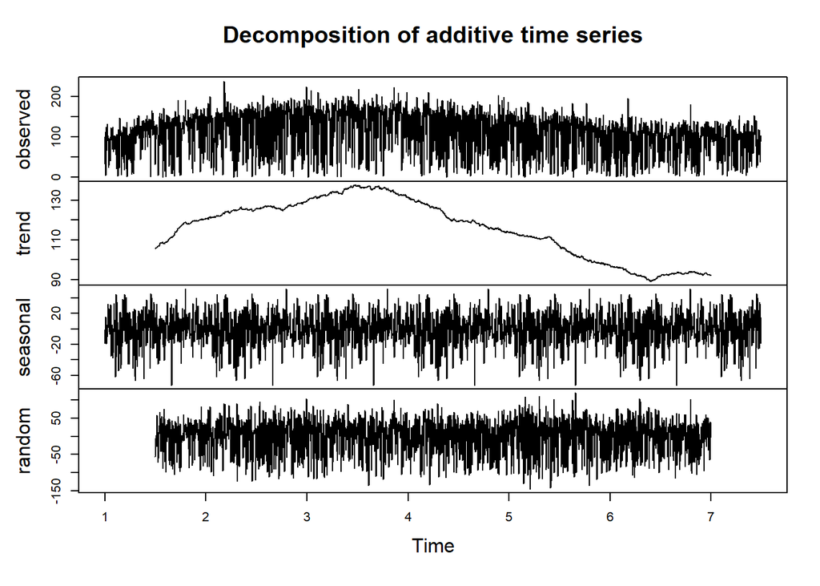

```r
countComps365 = decompose(countTS365, type="additive")
plot(countComps365)
```

Decompose car count time series assuming an additive model with a trend component and two seasonal components, using a TBATS state space model of the form  
y(t) = l(t-1) + phi * b(t-1) + s1(t) + s2(t) + e(t)  
where l(t) is the level, phi is a damping parameter, b(t) is the trend, s1(t) and s2(t) are the seasonalities, and e(t) is the error  
*For more details on TBATS models, see “Forecasting time series with complex seasonal patterns using exponential smoothing” by Hyndman, De Livera and Snyder*

Create multi-seasonal time series object under weekly and annual seasonality assumption

```r
countMSTS = msts(countXTS, seasonal.periods=c(7,365.25))
```

Create TBATS state space model with trend, weekly and annual components

```r
countTBATS = tbats(countMSTS)
```

Extract trend, weekly and annual seasonal components

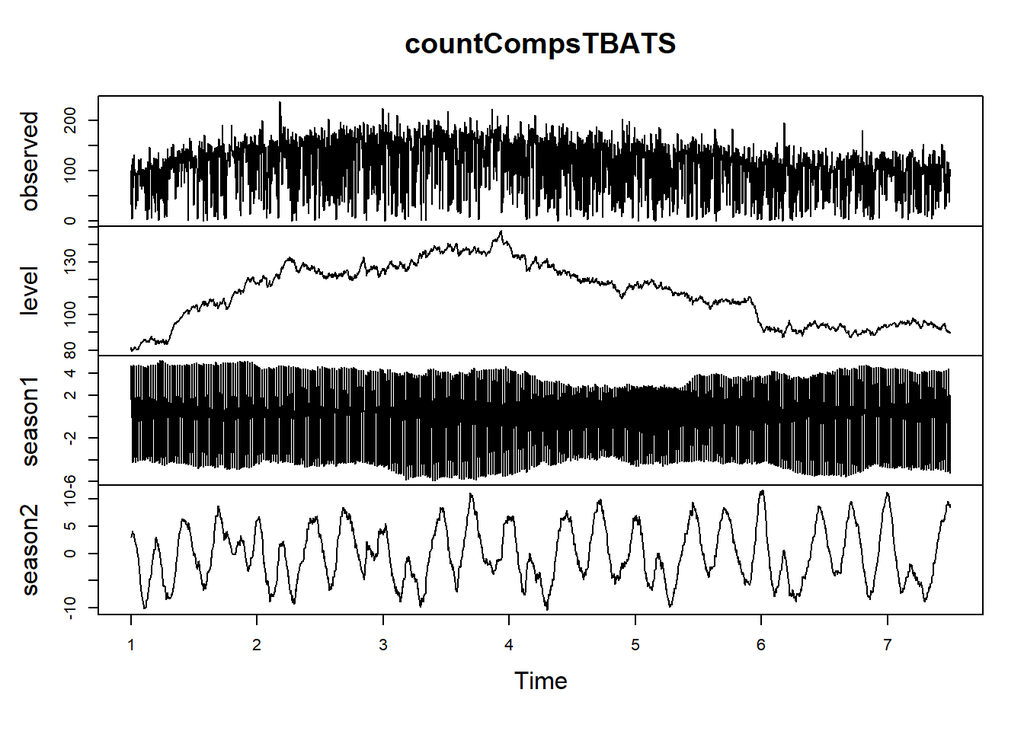

```r
countCompsTBATS = tbats.components(countTBATS)
plot(countCompsTBATS)
```

#### Discussion

Reviewing the above plot of the series decomposition with *annual* seasonality (the second of the three plots in this section), we observe that the trend is more consistent with our *a priori* expectation than was the case for the decomposition with weekly seasonality. This may indicate that, if we are limited to a single-seasonality decomposition, then annual seasonality is a more natural choice than weekly seasonality.

Reviewing the above plot of the series decomposition with *weekly and annual* seasonality (the third of the three plots in this section), we observe that the trend is basically consistent with our *a priori* expectation, but contains more high frequency variation than was the case for the decomposition with annual seasonality only. This may be an artifact of the fact different algorithms were used for the multiple-seasonality and single-seasonality decompositions, and degree of smoothing or high frequency filtering applied may differ. If we had more time, we would investigate this possibility.

The behavior of the annual seasonal component of the multiple-seasonal decomposition (labelled “season2” in the plot) may be explainable, at least in part, by our intuition about how consumer behavior varies over the course of the year. That is, there is a peak of activity at the end and very early begining of the year, *possibly* corresponding to the holiday buying season, followed by a sharp decline.

### Time Series Prediction

**Use the TBATS state space model to predict car counts as a function of trend, weekly and annual seasonal components**

Predict future values of car count with TBATS model, with trend, weekly and annual seasonal components

```r
countFcastTBATS = forecast(countTBATS)
print(class(summary(countFcastTBATS)))
```

```
##
## Forecast method: TBATS(1, {0,0}, -, {<7,2>, <365.25,6>})
##
## Model Information:
## TBATS(1, {0,0}, -, {<7,2>, <365.25,6>})
##
## Call: tbats(y = countMSTS)
##
## Parameters
##   Alpha: 0.01635905
##   Gamma-1 Values: -0.0002273389 -0.001453524
##   Gamma-2 Values: 0.0009679099 -0.0003319059
##
## Seed States:
##             [,1]
##  [1,] 81.0639797
##  [2,]  0.7435376
##  [3,]  0.8442952
##  [4,]  3.5440551
##  [5,]  1.7244662
##  [6,] -0.8284412
##  [7,]  0.4583797
##  [8,]  0.3416011
##  [9,]  0.5226219
## [10,]  1.5706173
## [11,]  1.0031655
## [12,] -1.9272061
## [13,] -2.3282483
## [14,]  2.6051452
## [15,] -2.8922466
## [16,]  1.3395706
## [17,]  1.9823569
##
## Sigma: 47.26174
## AIC: 36785.9
##
## Error measures:
##                     ME     RMSE      MAE  MPE MAPE      MASE       ACF1
## Training set 0.2262393 47.26174 38.88561 -Inf  Inf 0.6963056 0.04070725
##
```

[output cut: 19 more lines]

```
## 7.547945       90.11246 29.50606 150.7189  -2.57702773 182.8019
## 7.550685       91.09760 30.48780 151.7074  -1.59708950 183.7923
## 7.553425       84.60642 23.99248 145.2204  -8.09460719 177.3074
## 7.556164       82.81367 22.19574 143.4316  -9.89345175 175.5208
## 7.558904       90.12102 29.49982 150.7422  -2.59110804 182.8331
## 7.561644       91.45623 30.83053 152.0819  -1.26277033 184.1752
## 7.564384       86.13662 25.50438 146.7689  -6.59239473 178.8656
## 7.567123       86.75532 26.11686 147.3938  -5.98319490 179.4938
## 7.569863       87.91434 27.27018 148.5585  -4.83289171 180.6616
## 7.572603       81.61687 20.96606 142.2677 -11.14053851 174.3743
## 7.575342       80.03653 19.37927 140.6938 -12.73074243 172.8038
## 7.578082       87.57367 26.91091 148.2364  -5.20201335 180.3494
## 7.580822       89.15465 28.48488 149.8244  -3.63175964 181.9411
##  [ reached getOption("max.print") -- omitted 700 rows ]
## [1] "data.frame"
```

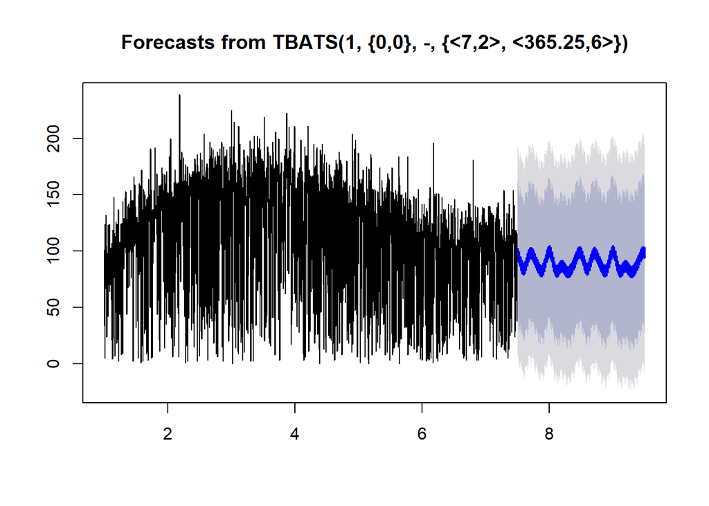

```r
plot(countFcastTBATS)
```

Predict future values of car count TBATS model with trend and weekly seasonal components

```r
# countSTS7 = msts(countXTS, seasonal.periods=c(7))
countSTS7 = ts(countXTS, freq=7)
countTBATS7 = tbats(countSTS7)
countFcastTBATS7 = forecast(countTBATS7)
print(class(summary(countFcastTBATS7)))
```

```
##
## Forecast method: TBATS(1, {0,0}, -, {<7,1>})
##
## Model Information:
## TBATS(1, {0,0}, -, {<7,1>})
##
## Call: tbats(y = countSTS7)
##
## Parameters
##   Alpha: 0.0174579
##   Gamma-1 Values: -0.0009610315
##   Gamma-2 Values: 0.001104881
##
## Seed States:
##            [,1]
## [1,] 83.0277320
## [2,]  0.7445704
## [3,]  3.5472376
##
## Sigma: 47.62467
## AIC: 36790.21
##
## Error measures:
##                    ME     RMSE      MAE  MPE MAPE      MASE       ACF1
## Training set 0.194484 47.62467 39.14496 -Inf  Inf 0.7888875 0.04452304
##
## Forecasts:
##          Point Forecast    Lo 80    Hi 80       Lo 95    Hi 95
## 340.0000       93.26592 32.23245 154.2994 -0.07671425 186.6086
## 340.1429       93.42961 32.38783 154.4714  0.07426969 186.7849
## 340.2857       91.82756 30.77620 152.8789 -1.54243595 185.1975
## 340.4286       89.66615 28.60407 150.7282 -3.72024375 183.0525
## 340.5714       88.57297 27.50010 149.6458 -4.82991745 181.9758
## 340.7143       89.37120 28.28863 150.4538 -4.04653528 182.7889
## 340.8571       91.45976 30.36879 152.5507 -1.97081482 184.8903
## 341.0000       93.26592 32.16715 154.3647 -0.17658188 186.7084
## 341.1429       93.42961 32.32254 154.5367 -0.02558437 186.8848
## 341.2857       91.82756 30.71092 152.9442 -1.64227435 185.2974
## 341.4286       89.66615 28.53880 150.7935 -3.82006464 183.1524
## 341.5714       88.57297 27.43485 149.7111 -4.92972073 182.0757
## 341.7143       89.37120 28.22338 150.5190 -4.14632271 182.8887
## 341.8571       91.45976 30.30355 152.6160 -2.07058855 184.9901
## [1] "data.frame"
```

Predict future values of car count TBATS model with trend and annual seasonal components

```r
# countSTS365 = msts(countXTS, seasonal.periods=c(365))
countSTS365 = ts(countXTS, freq=365)
countTBATS365 = tbats(countSTS365)
countFcastTBATS365 = forecast(countTBATS365)
print(class(summary(countFcastTBATS365)))
```

```
##
## Forecast method: BATS(1, {0,1}, -, -)
##
## Model Information:
## BATS(1, {0,1}, -, -)
##
## Call: tbats(y = countSTS365)
##
## Parameters
##   Alpha: 0.01611744
##   MA coefficients: 0.049705
##
## Seed States:
##          [,1]
## [1,] 83.39714
## [2,]  0.00000
##
## Sigma: 47.67182
## AIC: 36790.9
##
## Error measures:
##                     ME     RMSE      MAE  MPE MAPE      MASE          ACF1
## Training set 0.1921105 47.67182 39.09612 -Inf  Inf 0.7000749 -0.0009818734
##
## Forecasts:
##          Point Forecast    Lo 80    Hi 80      Lo 95    Hi 95
## 7.501370       91.02373 29.92983 152.1176  -2.411328 184.4588
## 7.504110       91.10994 29.88384 152.3360  -2.527306 184.7472
## 7.506849       91.10994 29.87511 152.3448  -2.540648 184.7605
## 7.509589       91.10994 29.86639 152.3535  -2.553989 184.7739
## 7.512329       91.10994 29.85767 152.3622  -2.567328 184.7872
## 7.515068       91.10994 29.84895 152.3709  -2.580664 184.8005
## 7.517808       91.10994 29.84023 152.3797  -2.593999 184.8139
## 7.520548       91.10994 29.83151 152.3884  -2.607332 184.8272
## 7.523288       91.10994 29.82279 152.3971  -2.620663 184.8405
## 7.526027       91.10994 29.81408 152.4058  -2.633992 184.8539
## 7.528767       91.10994 29.80536 152.4145  -2.647320 184.8672
## 7.531507       91.10994 29.79665 152.4232  -2.660645 184.8805
## 7.534247       91.10994 29.78794 152.4319  -2.673969 184.8938
## 7.536986       91.10994 29.77923 152.4407  -2.687290 184.9072
## 7.539726       91.10994 29.77052 152.4494  -2.700610 184.9205
## 7.542466       91.10994 29.76181 152.4581  -2.713928 184.9338
## 7.545205       91.10994 29.75310 152.4668  -2.727244 184.9471
## 7.547945       91.10994 29.74440 152.4755  -2.740558 184.9604
## 7.550685       91.10994 29.73569 152.4842  -2.753870 184.9737
## 7.553425       91.10994 29.72699 152.4929  -2.767180 184.9871
## 7.556164       91.10994 29.71829 152.5016  -2.780489 185.0004
## 7.558904       91.10994 29.70959 152.5103  -2.793795 185.0137
## 7.561644       91.10994 29.70089 152.5190  -2.807100 185.0270
## 7.564384       91.10994 29.69219 152.5277  -2.820403 185.0403
## 7.567123       91.10994 29.68349 152.5364  -2.833703 185.0536
## 7.569863       91.10994 29.67480 152.5451  -2.847002 185.0669
## 7.572603       91.10994 29.66610 152.5538  -2.860299 185.0802
## 7.575342       91.10994 29.65741 152.5625  -2.873595 185.0935
## 7.578082       91.10994 29.64872 152.5712  -2.886888 185.1068
## 7.580822       91.10994 29.64003 152.5799  -2.900179 185.1201
##  [ reached getOption("max.print") -- omitted 700 rows ]
## [1] "data.frame"
```

Create a linear regression model to predict car count as a function of year, month, day of week and cloud indicator, of the form  
y(t) = x1(t) + x2(t) + x3(t) + x4(t) + e(t)  
where x1(t), x2(t), x3(t) and x(4) are categorical predictor variables representing the year, month, day of week and cloud indicator, and e(t) is the error

Create data frame comprising car count as a numerical variable, and year, month, day of week and cloud indicator as categorical variables

```r
dataDF2 = data.frame(count=dataDF$car.count,
                     year = factor(year(dataDF$date)),
                     month = factor(month(dataDF$date)),
                     day = factor(wday(dataDF$date)),
                     cloud = factor(dataDF$cloud.indicator))
```

Create linear regression model

```r
linearModel = lm(count ~ year + month + day + cloud, data=dataDF2)
print(summary(linearModel))
```

```
##
## Call:
## lm(formula = count ~ year + month + day + cloud, data = dataDF2)
##
## Residuals:
##     Min      1Q  Median      3Q     Max
## -95.571 -17.214  -0.544  16.431 120.248
##
## Coefficients:
##             Estimate Std. Error t value Pr(>|t|)
## (Intercept) 129.4669     3.0560  42.364  < 2e-16 ***
## year2011     26.2562     2.2980  11.426  < 2e-16 ***
## year2012     33.9193     2.2945  14.783  < 2e-16 ***
## year2013     19.9946     2.2983   8.700  < 2e-16 ***
## year2014      7.0050     2.2978   3.048  0.00233 **
## year2015    -10.3360     2.2965  -4.501  7.1e-06 ***
## year2016    -12.8366     2.8925  -4.438  9.5e-06 ***
## month2        6.1064     3.0566   1.998  0.04585 *
## month3        9.8075     2.9825   3.288  0.00102 **
## month4        0.2597     3.0048   0.086  0.93112
## month5        5.2595     2.9775   1.766  0.07746 .
## month6       10.7291     3.0030   3.573  0.00036 ***
## month7        7.0877     3.1228   2.270  0.02332 *
## month8        4.4441     3.1215   1.424  0.15467
## month9        8.5088     3.1470   2.704  0.00691 **
## month10       6.2863     3.1193   2.015  0.04399 *
## month11       2.7861     3.1468   0.885  0.37605
## month12       8.4917     3.1219   2.720  0.00658 **
## day2         -1.2966     2.3823  -0.544  0.58630
## day3         -3.0934     2.3823  -1.298  0.19425
## day4         -3.8465     2.3822  -1.615  0.10652
## day5         -3.9875     2.3823  -1.674  0.09430 .
## day6         -3.1688     2.3831  -1.330  0.18375
## day7          2.7766     2.3823   1.165  0.24394
## cloudcloudy -73.3265     1.2976 -56.508  < 2e-16 ***
## ---
## Signif. codes:  0 '***' 0.001 '**' 0.01 '*' 0.05 '.' 0.1 ' ' 1
##
## Residual standard error: 31.01 on 2348 degrees of freedom
## Multiple R-squared:  0.6211, Adjusted R-squared:  0.6172
## F-statistic: 160.4 on 24 and 2348 DF,  p-value: < 2.2e-16
```

#### Discussion

First we predicted and plotted the car count time series using the TBATS model with both weekly and annual seasonal components. Reviewing the above plot of the prediction with weekly and annual seasonality, we notice that the predicted series seems to reflect the seasonal components of the previously observed series, but seems to assume no change in central tendency due to long term trend. If we had more time, we would investigate this further.

Last we created a predictive model using linear regression, with car count as the target, and year, month, day of week and cloud indicator as categorical predictors. This may be an unconventional approach for time series data, but we took this approach because: (1) it provided a relatively simple way to incorporate information about the other variables observed into our prediction of car count; and (2) it allowed us to analyze the data from a different perspective while using a well-understood predictive algorithm. The R-squared value for this model was 0.62, indicating that there is potential this approach to predicting the car count. The residual standard error is 31.01. Future work would include investigating whether the residual standard error reported by the linear model in R is directly comparable to the RMSE values reported by the TBATS models.

Moreover, future work would focus on the more fundamental challenge of creating a model which combines trend and seasonality information from the car count time series, with information from the other variables observed (i.e. weather and cloud indicator), to obtain more accurate predictions.